# EDAPHIC FACTORS AND THE LANDSCAPE‐SCALE DISTRIBUTIONS OF TROPICAL RAIN FOREST TREES - Clark - 1999 - Ecology - Wiley Online Library

CIRAD - DGDRS - DIST

[Ecology](https://esajournals.onlinelibrary.wiley.com/journal/19399170)

[Volume 80, Issue 8](https://esajournals.onlinelibrary.wiley.com/toc/19399170/1999/80/8) p. 2662-2675

[figure not shown]

Article

Full Access

# EDAPHIC FACTORS AND THE LANDSCAPE-SCALE DISTRIBUTIONS OF TROPICAL RAIN FOREST TREES

[David B. Clark](https://esajournals.onlinelibrary.wiley.com/authored-by/Clark/David+B.),

[Michael W. Palmer](https://esajournals.onlinelibrary.wiley.com/authored-by/Palmer/Michael+W.),

[Deborah A. Clark](https://esajournals.onlinelibrary.wiley.com/authored-by/Clark/Deborah+A.),

First published: 01 December 1999

https://doi.org/10.1890/0012-9658(1999)080[2662:EFATLS]2.0.CO;2

Citations: 312

## Abstract

For a variety of reasons, including issues relating to sample size and adequate edaphic characterization of landscapes, we suggest that the ∼30% of species shown to be edaphically biased in this study is an underestimate of the true degree of edaphically related distributional biases. To evaluate this hypothesis will require mesoscale vegetation sampling combined with quantitative soil analyses at the same scale in a range of tropical rain forests. If edaphic distributional biases are shown to be common, this suggests that edaphically linked processes leading to differential recruitment are similarly common.

## Introduction

Two characteristics distinguish lowland tropical rain forests (TRF) from other terrestrial biomes: they harbor the highest density of tree species, and most of these species are locally rare. There can be >300 tree species/ha in TRF (Valencia et al. 1994), and the median density of trees ≥10 cm diameter is ≤1 individual·species<sup>−1</sup>·ha<sup>−1</sup> (Valencia et al. 1994, data in Lieberman et al. 1985*a*). How do all these species coexist? Are there really >300 distinct ways per hectare to partition the basic requirements of plant life; i.e., water, light, nutrients, and physical space? Or are other factors such as chance or history playing a decisive role (Poore 1968, Hubbell and Foster 1986*a*)? The answers to these questions are critical to understanding how tropical forest landscapes are organized and how they might be maintained in the future.

One route for maintaining the high local diversity of TRF trees could be nonrandom distributions related to edaphic factors (Ashton 1969, Gentry 1981). If tree species are nonrandomly distributed among edaphic patch types and patch types are mixed over the landscape, under certain conditions this could lead to higher numbers of species at the regional scale. Working at the plot or transect scale, several researchers have indeed demonstrated significant edaphic biases (i.e., nonrandom associations with the analyzed factors) of old-growth TRF plant species (Newbery and Proctor 1984, Hubbell and Foster 1986*b*, Basnet 1992, Gentry and Ortiz 1993, Tuomisto and Ruokolainen 1994, Poulsen 1996). Other studies have demonstrated broad edaphic biases at much larger spatial scales (Baillie et al. 1987, Swaine 1996).

There is an intermediate spatial scale, however, that is critical to understanding the role of edaphic effects on TRF plant communities and that has been little studied. This is the scale from ∼1 to 100 km<sup>2</sup>, which we term a “mesoscale landscape” (Heikkinen 1996). Landscapes of this size are larger than those investigated in most plot studies, but are smaller than major river basins. At this scale tropical forest landscapes are complex mosaics of edaphic types (Gartlan et al. 1986, ter Steege et al. 1993, Duivenvoorden 1995, Tuomisto et al 1995, Clark et al. 1998). Our goal in this research was to assess the extent of edaphically biased distributions of TRF tree species over such a mesoscale landscape.

Any landscape-level study in tropical rain forest faces two major challenges. One is unique to the tropics: the extreme rarity of most species. We addressed this issue by using highly replicated sampling and by developing randomization methods for analyzing species with low sample size. We also used multivariate analyses to assess the major gradients in species composition and to determine their environmental correlates. The second challenge is common to all studies where the objectives include landscape-scale inference: how does one take a representative sample of an entire landscape (Botkin and Simpson 1990)? Plot-based studies tend to be either unreplicated for studies of edaphic factors, or based on sites deliberately chosen to minimize topographic variation. To obtain unbiased estimates of both the vegetation and edaphic factors over our study area, a mesoscale landscape of old-growth TRF, we used a regularly spaced sample grid covering the entire area.

We found that edaphically biased distributions were common. At the same time, we discovered some important limitations of these types of analyses. This led us to consider the implications of these limitations, and to suggest that the data presented here present a minimum estimate of edaphic biases in old-growth TRF. Finally, we build on the results of this work to suggest new directions for research on mesoscale edaphic variation and its impact on the structure of TRF plant communities.

## Methods

The study was carried out in a 573-ha area of old-growth forest (Clark 1996) at the La Selva Biological Station in the Atlantic lowlands of the Republic of Costa Rica. The area is a mosaic of several distinct edaphic zones (Sollins et al. 1994): alluvial terraces formed by contemporaneous or historic flooding, areas of residual soil formed by in-place weathering of lava flows, swamps, and infertile colluvial soils of small stream valleys (Fig. 1). Elevation within the study area ranged from ∼34 to 131 m above sea level.

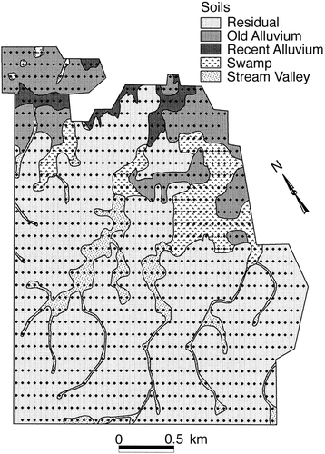

**Figure 1**

Open in figure viewer[PowerPoint](https://esajournals.onlinelibrary.wiley.com/action/downloadFigures?id=i0012-9658-80-8-29-f01&doi=10.1890%2F0012-9658%281999%29080%5B2662%3AEFATLS%5D2.0.CO%3B2)

The distribution of soil types and the locations of vegetation plots at the La Selva Biological Station, Costa Rica. A 0.01-ha quadrat was established at each grid point. Soils data are taken from Clark et al. (1998).

Trees and palms ≥10 cm in diameter were counted and identified to species or morphospecies in 1170 circular 0.01-ha plots centered on the posts of a previously established 50 × 100 m grid that covers the La Selva reserve (D. A. Clark 1998). Four people determined species identifications in the field: D. B. Clark, D. A. Clark, and two local technicians (Leonel Campos and William Miranda). Prior to the field work this group worked together in the La Selva arboretum and herbarium to develop a list of species that could be reliably identified in the field. Species that could not be consistently identified were always collected. A shotgun was used for collecting from taller trees. Vouchers were subsequently identified by the four field identifiers, Orlando Vargas (La Selva’s Station Naturalist), Nelson Zamora (Instituto Nacional de Biodiversidad de Costa Rica), and Barry Hammel and Michael Grayum (Missouri Botanical Garden). Vouchers for all species are currently stored at La Selva. A list of the species’ names, species’ authorities, and a voucher number in a public collection for all species discussed in this article is given in the Appendix. A complete listing for all the species will be published separately (D. B. Clark, D. A. Clark, L. Campos, W. Miranda, and O. Vargas, *unpublished data.*)

Within each 0.01-ha plot, slope angle at the grid point was measured with a clinometer over a distance of 2 m in the direction of greatest slope, and aspect was determined with a compass. Topographic position of the plot was classified as one of four categories: flat/ridgetop, upper slope, mid-slope, base of slope/riparian. We used an existing data set on soil type that was based on sampling in each plot; development of this database is described in Clark et al. (1998). Briefly, a soil sample at 40–50 cm depth was collected adjacent to the grid point. Soil samples were classified based on color, slope position, elevation, and geographic location into one of five soil types following the concepts developed by Sancho and Mata (1987) and further amended by Sollins et al. (1994) and Clark et al. (1998). The soil types were: Residual soils (well-drained high-clay, low-nutrient soils formed by weathering of lava flows, mainly ultisols), Stream Valley soils (colluvial high-clay soils washed off the ultisol ridges, moderately drained, acidic and low nutrient content), Old Alluvial soils (well drained high-clay inceptisols of intermediate nutrient status), Recent Alluvial soils (moderately drained sandier soils of high fertility), and Swamp soils (poorly drained, acid, high-clay gleyed and mottled soils). Further details on soil classification and underlying site geology are given by Sollins et al. (1994) and Clark et al. (1998).

We used multivariate analyses to look for floristic and environmental gradients in the data, and to assess the relative importance of environmental factors in determining the observed species distributions. We used the program CANOCO (ter Braak 1987, 1988*a*) version 3.12 to perform a Detrended Correspondence Analysis (DCA) and Canonical Correspondence Analysis (CCA) on all 940 plots with at least three tree stems. We checked our results with CANOCO 4 (ter Braak and Šmilauer 1998) to confirm that the DECORANA bug (Oksanen and Minchin 1997) did not influence the outcome. DCA is an indirect gradient analysis technique (Hill and Gauch 1980) that detects gradients in species composition from species abundance data. DCA simultaneously ordinates species and samples, so that one can immediately relate species to the samples in which they occur. CCA is a direct gradient analysis technique (ter Braak and Prentice 1988) that relates species composition to measured environmental variables. Environmental variables included in the CCA were slope, aspect, elevation, soil type, and topographic variables. Because aspect is a circular variable, we transformed it into two derived variables, northness = cosine(aspect) and eastness = sine(aspect). We coded soil type and topography as dummy (1/0) variables. We performed two CCAs: one with all variables included, and a second with only soil types included.

CANOCO permits partial analyses in which the effects of covariables are factored out (ter Braak 1988*b*). In addition to the analyses described above, we performed a partial CCA in which the effects of soil type were factored out, and a partial DCA in which the effects of all measured variables were factored out. This partial DCA will determine if there are residual gradients in species composition that are unrelated to topography or soil types.

We were also interested in topographic biases within a given soil type. We calculated the WPI for species’ occurrence among the four topographic positions within the dominant soil type (Residual), for species occurring in at least five plots on that soil. We then compared these indices to the 95th percentile values from randomizations for each sample size based on 500 samples drawn randomly and without replacement from the Residual soil plots.

## Results

### Species diversity and frequency

We encountered a total of 5127 individuals belonging to 267 species of trees and palms. Trees accounted for 261 species and 3819 individuals, while palms totaled 6 species and 1308 individuals. *Pentaclethra macroloba* (Mimosoideae) was the most common species, with 13.6% of all stems. The next three most common species were palms (Arecaceae): *Iriartea deltoidea* (7.7% of stems), *Socratea exorrhiza* (7.7%), and *Welfia regia* (7.5%). Rare species, those occurring at a density of ≤1 individual/ha, comprised 74% of the total species sample. Of the 267 species, 57 (21%) were represented by only a single individual among the 5127 stems.

### Multivariate analyses of species distribution

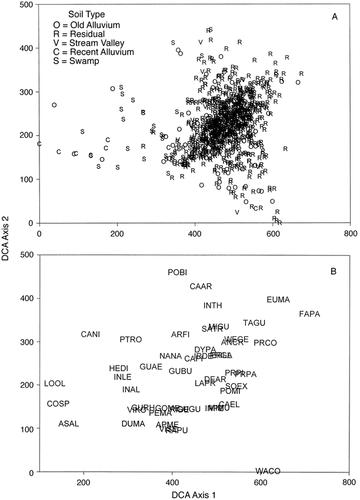

**Figure 2**

Open in figure viewer[PowerPoint](https://esajournals.onlinelibrary.wiley.com/action/downloadFigures?id=i0012-9658-80-8-29-f02&doi=10.1890%2F0012-9658%281999%29080%5B2662%3AEFATLS%5D2.0.CO%3B2)

Detrended Correspondence Analysis. Axes are scaled in 100 × sd beta diversity units (Hill and Gauch 1980). (A) Sample scores. (B) Species scores of the 48 most abundant species. Summary statistics are given in Table 1A. Species abbreviations in (B) correspond to the first two letters of the genus and species given in the Appendix.

Table 1. Results of multivariate analyses of species distributions using only species data (stem counts)(DCA) or species occurrences including environmental data (CCA).

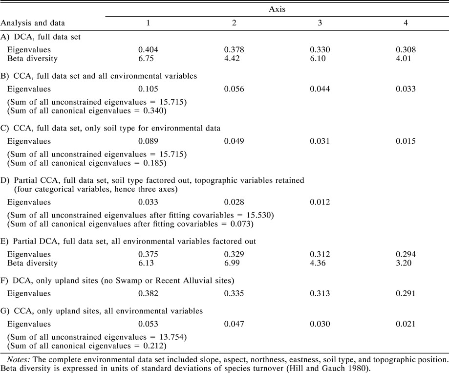

Direct gradient analysis using CCA revealed that tree species composition is related to both soil type and topography. The first CCA axis segregates steeper, higher elevation sites (usually midslopes or upper slopes on Residual soils) from flat swampy sites and sites on Recent Alluvium (Fig. 3). This reconfirms the major swamp–upland gradient found with the DCA (Fig. 2), and the species scores along the first CCA axis (not shown) are very similar to those along the first DCA axis (Fig. 2*b*), although in reversed order. The second CCA axis segregates soil types in the sequence Swamp, Stream Valley, Residual Soil, Old Alluvium, and Recent Alluvium and may represent either a soil texture gradient and/or a soil oxygen gradient. The first CCA axis, as well as the overall analysis, was statistically significant (*P* < 0.0001). Nevertheless, the CCA eigenvalues were substantially lower than those of the corresponding DCA, and the environmental variables only explained a small portion (2.2%) of the variance in species composition. This indicates that there is substantial noise in species composition (a certainty with small plots) and/or that other unmeasured gradients are important.

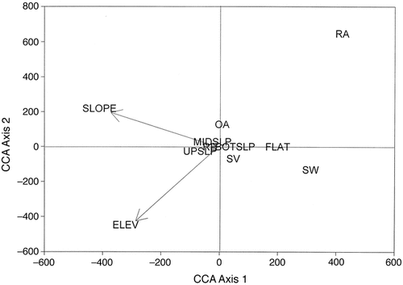

**Figure 3**

Open in figure viewer[PowerPoint](https://esajournals.onlinelibrary.wiley.com/action/downloadFigures?id=i0012-9658-80-8-29-f03&doi=10.1890%2F0012-9658%281999%29080%5B2662%3AEFATLS%5D2.0.CO%3B2)

Canonical Correspondence Analysis scores for environmental variables. Categorical variables (soil type, topographic position) are represented by plot centroids; continuous variables (elevation, slope) are represented by “biplot arrows.” Soils types are SW = Swamp, OA = Old Alluvium, SV = Stream Valley, RE = Residual, RA = Recent Alluvium. Topographic positions are FLAT = ridgetop or flat, UP = top of slope, MID = mid-slope, BASE = base of slope.

It may seem counterintuitive that the frequently flooded and chemically reduced Swamp soils are not more extreme along the first axis than the fertile, infrequently flooded Recent Alluvium. This might be because the three common palms (*W. regia, I. deltoidea,* and *S. exorrhiza*) occur occasionally in Swamps but rarely on Recent Alluvium. Alternatively, soils classified as Swamps might include slightly elevated microsites (as found by Lieberman et al. 1985*b*) and therefore include species more typical of upland sites.

A CCA using soils as the only environmental variable (Table 1C) revealed centroids of soil types and species scores (not shown) virtually identical to the CCA using all environmental variables, reconfirming a swamp to upland gradient. A partial CCA test (ter Braak 1988*b*) with soil types as covariables revealed that within soil types, topographic position is highly significantly related to species composition (*P* < 0.001 for the first eigenvalue and for the overall analysis, Table 1D). The topographic categories were arranged along the first axis in the order: Upper Slope, Mid-slope, Base of Slope, and Flat. The second axis separated Base of Slope from Flat. Species scores indicated preferences consistent with the topographic WPI analysis.

We also performed a partial DCA factoring out all of the environmental variables (Table 1E). The eigenvalues and beta diversities of the first two axes are quite high, implying there is much variation in species composition that was not explained by our environmental variables. The species scores and sample scores along the first partial DCA axis (not shown) are almost identical to that of the second DCA axis (Fig. 2). We were not able to interpret the gradient biologically.

To examine a shorter edaphic gradient, we excluded the fertile Recent Alluvial sites as well as the frequently flooded Swamp sites (Table 1F and G). The overall results were similar to the analysis of the full data set. The DCA was highly significant, but in the CCA environmental factors explained a minimal portion of the variation in species’ distributions. Old Alluvial sites were at one end of CCA Axis 1, with the less fertile Residual and Stream Valley sites at the other extreme. The second CCA axis separated sites on steeper slopes and at intermediate slope positions from flatter sites such as terraces, hilltops, and slope bases.